# Data Visualization R Project1

## Mohammad Chauhan & Patricia O’brien

```r
source("../02 Data Wrangling/Data_Wrang1.R", echo = TRUE)
```

```
##
## > require("jsonlite")
```

```
##
## > require("RCurl")
```

```
##
## > require("dplyr")
```

```
##
## > require("ggplot2")
```

```
##
## > df <- data.frame(fromJSON(getURL(URLencode("129.152.144.84:5001/rest/native/?query=\"select * from EMPLOYEE_SALARIES__2014\""),
## +     httpheader =  .... [TRUNCATED]
##
## > summary(df)
##              FULL_NAME    GENDER     DEPARTMENT
##  Carter, Jerome   :   2   F:3713   POL    :1840
##  Cruz, Angela     :   2   M:5387   HHS    :1550
##  Aarhus, Pam J    :   1            FRS    :1309
##  Aaron, David J   :   1            DOT    :1186
##  Aaron, Marsha M  :   1            COR    : 499
##  Ababio, Godfred A:   1            DGS    : 430
##  (Other)          :9092            (Other):2286
##                                 DEPARTMENT_NAME
##  Department of Police                   :1840
##  Department of Health and Human Services:1550
##  Fire and Rescue Services               :1309
##  Department of Transportation           :1186
##  Correction and Rehabilitation          : 499
##  Department of General Services         : 430
##  (Other)                                :2286
##                                        DIVISION
##  School Health Services                    : 297
##  Transit Silver Spring Ride On             : 277
##  Transit Gaithersburg Ride On              : 273
##  Highway Services                          : 217
##  Child Welfare Services                    : 199
##  FSB Traffic Division School Safety Section: 166
##  (Other)                                   :7671
##        ASSIGNMENT_CATEGORY                             POSITION_TITLE
##  Fulltime-Regular:8244     Police Officer III                 : 886
##  Parttime-Regular: 856     Firefighter/Rescuer III            : 697
##                            Bus Operator                       : 606
##                            Manager III                        : 245
##                            Correctional Officer III (Corporal): 234
##                            Office Services Coordinator        : 218
##                            (Other)                            :6214
##                      UNDERFILLED_JOB_TITLE   DATE_FIRST_HIRED
##  null                           :7982      01/14/2013:  90
##  Firefighter/Rescuer II         : 255      02/24/2014:  77
```

[output cut: 53 more lines]

```
## 2       09/18/1986              92931.18                 92918.97
## 3       01/08/2007              42275.19                 45994.09
## 4       02/12/1990              64448.13                 84670.63
## 5       04/19/1998              61304.10                102366.62
## 6       11/13/2000              69336.83                 74656.37
##   X2014_OVERTIME_PAY
## 1     25119.48046875
## 2    1038.5400390625
## 3   6138.18994140625
## 4     21400.51953125
## 5     40977.44140625
## 6      5471.66015625
##
## > df %>% group_by(GENDER, DEPARTMENT) %>% summarise(mean_salary = mean(CURRENT_ANNUAL_SALARY)) %>%
## +     ggplot(aes(x = DEPARTMENT, y = mean_salary,  .... [TRUNCATED]
```

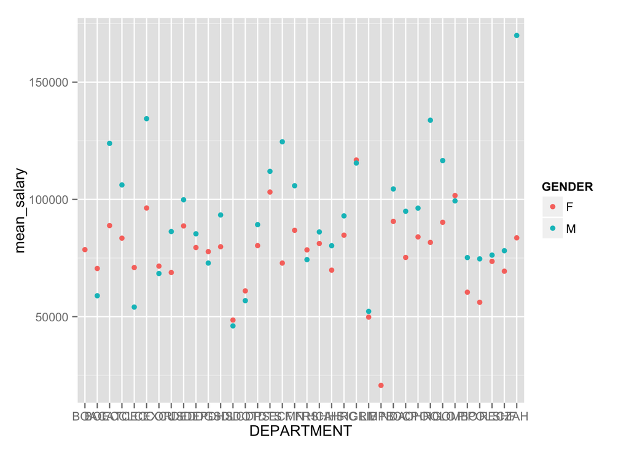

In this graph we plotted the average salary of each department by gender. The points tell us that the females’ average salary in each department is generally below $100,000. However, there are several departments where the males’ average salary s well above $100,000. The Office of Zoning and Administrative Hearings (ZAH) had the greatest average salary disparity between genders. Nine of the departments had higher average female salaries, but there wasn’t a large difference between male average salary in the respective departments.

```r
source("../02 Data Wrangling/Data_Wrang2.R", echo = TRUE)
```

```
##
## > require("jsonlite")
##
## > require("RCurl")
##
## > require("dplyr")
##
## > require("ggplot2")
##
## > df <- data.frame(fromJSON(getURL(URLencode("129.152.144.84:5001/rest/native/?query=\"select * from EMPLOYEE_SALARIES__2014\""),
## +     httpheader =  .... [TRUNCATED]
##
## > df %>% mutate(price_percent = cume_dist(X2014_GROSS_PAY_RECEIVED)) %>%
## +     filter(DEPARTMENT %in% c("PIO", "OHR", "HCA", "CAT", "CEC",
## +         .... [TRUNCATED]
```

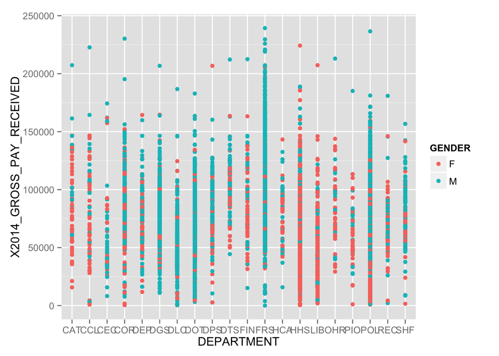

Here we plotted the salaries of employees in the top 20 departments with the most people. Only 6 departments had more female than male employees. The department with the most males was the Fire and Rescue Services Department, while the department with the most females was the Department of Health and Human Services. As we can see, there are a 3 female employees that make over $200,000, but there are far more male employees that make more than $200,000. We can also see in the Department of Police that the females salaries cluster under $50,000, but there are many males who make more than $50,000. One thing to consider is that there are more males in the Fire and Rescue Services Department. The positions in this department might be more dangerous or require more specialization compared to the Department of Health and Human Services, which is the department with the most females.

```r
source("../02 Data Wrangling/Data_Wrang3.R", echo = TRUE)
```

```
##
## > require("jsonlite")
##
## > require("RCurl")
##
## > require("dplyr")
##
## > require("ggplot2")
##
## > df <- data.frame(fromJSON(getURL(URLencode("129.152.144.84:5001/rest/native/?query=\"select * from EMPLOYEE_SALARIES__2014\""),
## +     httpheader =  .... [TRUNCATED]
##
## > df %>% group_by(GENDER) %>% ggplot(aes(x = GENDER,
## +     y = X2014_GROSS_PAY_RECEIVED, color = ASSIGNMENT_CATEGORY)) +
## +     geom_boxplot()
```

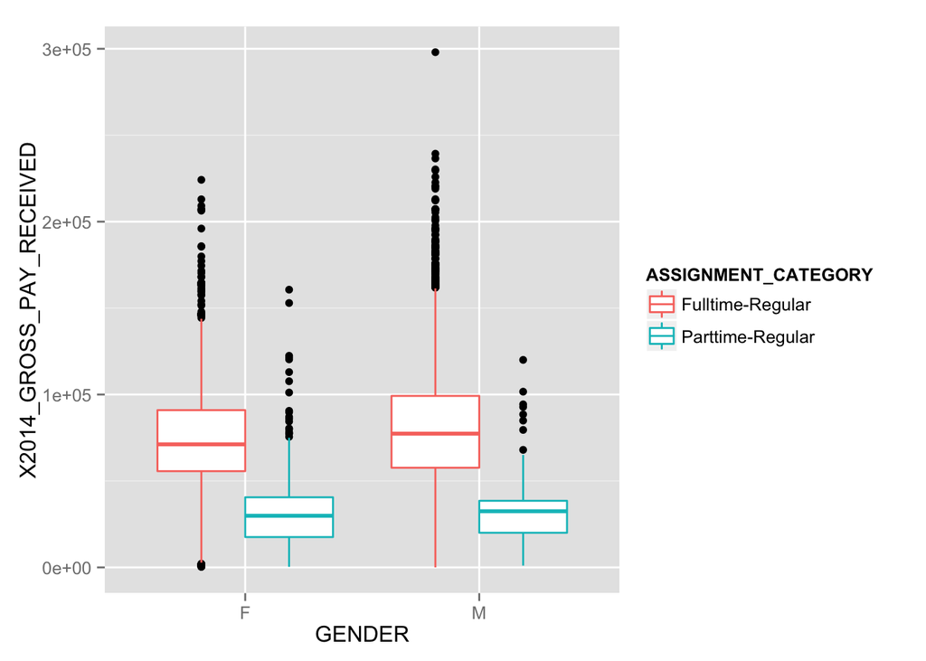